# Updates and In-Class Assignments

# In-class Writing: Choose Your Own Adventure (11/30)

For today’s class, you chose a game to play from a list. Some of you may have chosen the same game, but hopefully you all did not. To start our conversation, then, we need to do a little bit of description and basic analysis. To that end, I’d like you to answer the following questions about the game you played:

1. Imagine you were charged with writing the description of this game for a web store or the back of a case. Can you summarize the game in a few sentences? What is it about? Why might it be interesting to play?
2. What is the primary *mechanic* of the game? That is, how do players primarily interact with the game: e.g. through some style of movement, by managing resources, through simulated combat, etc.? Is the game’s mechanic similar to other games you know of, or does it seem notably distinct?
3. How would you describe the *style* of the game? Consider its visual style, its aural style, and (if applicable) its textual style. Do these different elements work in harmony or do they seem at odds with each other? What does the game’s style seem to convey, and does it succeed?
4. Is there a *narrative* in this game? If so, would you describe the narrative as *scripted* or *emergent*—that is, does the game proceed through a set series of narrative moments, or does the player participate in creating the narrative through playing the game?
5. Does your game explore particular *themes* or *ideas* through its mechanic, style, or narrative (or some combination thereof)? How are these themes and/or ideas articulated? Does the game seem aimed at giving players a particular view of these themes and/or ideas, or does it seem designed to provoke independent thinking?
6. Finally, is your game fun? Why or why not? How do the elements discussed above contribute to the fun of the game (or lack thereof)?

# In-class Group Work: Escape the Matrix (11/15)

Toward the beginning of her article, [“Escape the Matrix,”](https://www.wired.com/2017/08/uncanny-valley-internet/) Virginia Heffernan claims that a central problem facing us when trying to grapple with the changes brought on by the internet is that of metaphor:

> The cycle of doubt and self-doubt—bitcoin sounds fishy; I’m an idiot for thinking bitcoin sounded fishy—can turn palpable, somatic. And that’s when it starts to seem clear that what we’re doing with software is not just interacting with machines, something our emotionally detached left brains can deal with. What we’re doing still, after all these years, is seeking serviceable metaphors that will make sense of the digital onslaught, trying to match its many facets, in scale and tenor, with traditional human experiences.

> Of course, every metaphor carries its own baggage. For example, maybe bitcoin is “money.” Money surfaces all the emotional chaos surrounding credit, debt, thrift, riches, banks, bankruptcy. Or maybe bitcoin is a weapon, or cult esoterica. Maybe it’s the dark internet or benign nonsense. With any of those hypotheses comes a set of associations, aversions, even attractions. At the same time, metaphors are poor things that never adequately illuminate the things they stand in for. We’re practiced in the old connections from glittery gold to paper dollars to all that money connotes, but connecting bitcoin (which I defy any reader to clearly picture) to good old coins, the minted ingots used by our grandpas and ancient Romans alike, is a taxing mental operation.

This recalls the idea of the skeuomorph that we discussed many weeks ago: the symbolic and linguistic metaphors drawn from older media that we use to understand newer media. Recall, for instance, our discussion of the iPhone’s voicemail icon, which recalls the cassette tape reels used by early answering machines, or the save icon of a floppy disk, hardware no one uses to save anything anymore.

Once you start looking for them, visual skeuomorphs are relatively easy to identify (provided you know their historical referents). The conceptual skeuomorphs Heffernan discusses—e.g. is bitcoin really “money,” or is it something else altogether?—are perhaps harder to pinpoint. But that harder work is precisely what I want you to do in your groups today. Working together, identify 2-3 specific metaphors of internet culture and/or technologies that fail to adequately convey the new paradigms they describe. It may be that the metaphors fail to convey a realistic sense of how the technologies operate, or fail to convey the political-social effects from the technologies.

In your groups, you should outline 1. what the skeuomorphic metaphors are, 2. why the historical referent fails to fully describe the contemporary technology, and 3. what consequences stem from that failed metaphor.

# In-class Exercise: Time is Money (11/13)

Consider these excerpts from [Henry David Thoreau’s *Walden*](https://www.gutenberg.org/files/205/205-h/205-h.htm):

> the cost of a thing is the amount of what I will call life which is required to be exchanged for it, immediately or in the long run…

> As with our colleges, so with a hundred “modern improvements”; there is an illusion about them; there is not always a positive advance. The devil goes on exacting compound interest to the last for his early share and numerous succeeding investments in them. Our inventions are wont to be pretty toys, which distract our attention from serious things. They are but improved means to an unimproved end, an end which it was already but too easy to arrive at; as railroads lead to Boston or New York. We are in great haste to construct a magnetic telegraph from Maine to Texas; but Maine and Texas, it may be, have nothing important to communicate…

> One says to me, “I wonder that you do not lay up money; you love to travel; you might take the cars and go to Fitchburg today and see the country.” But I am wiser than that. I have learned that the swiftest traveller is he that goes afoot. I say to my friend, Suppose we try who will get there first. The distance is thirty miles; the fare ninety cents. That is almost a day’s wages. I remember when wages were sixty cents a day for laborers on this very road. Well, I start now on foot, and get there before night; I have travelled at that rate by the week together. You will in the meanwhile have earned your fare, and arrive there some time tomorrow, or possibly this evening, if you are lucky enough to get a job in season. Instead of going to Fitchburg, you will be working here the greater part of the day. And so, if the railroad reached round the world, I think that I should keep ahead of you; and as for seeing the country and getting experience of that kind, I should have to cut your acquaintance altogether.

How might we put these ideas together with those of Thurston and Bogost from our reading today? Are Thoreau’s ideas about the telegraph and the railroad—two technologies dramatically reshaping communication and even notions of time in the mid nineteenth century—conversant with Thurston’s and Bogost’s ideas about the internet and social media today? How so or how not?

# In-class Exercise: What Gorilla? (11/8)

In *Now You See It*, Cathy Davidson argues (among other things) that our current educational system is designed to train minds to operate within a largely industrial system that has since been largely replaced. She argues that we need to wholly rethink how we educate students if we want to prepare them to thrive within current—not future, but current—intellectual, economic, and social structures (a similar argument to that made by Northeastern’s own president, Joseph Aoun, in his new book [*Robot Proof: Education in the Age of Artificial Intelligence*](https://www.amazon.com/Robot-Proof-Higher-Education-Artificial-Intelligence/dp/0262037289/ref=asap_bc?ie=UTF8). However, many of the most loudly touted educational reformations, such as MOOCs or laptops in the classroom, have seen decidedly mixed results, and have largely not brought about the revolutions their backers claimed were imminent.

Today we’ll work in small groups. We will pretend that your groups have been charged with restructuring the classroom to better meet the needs of today’s students. Since college is your most immediate educational context, you can focus on the college classroom as you have experienced it. You probably can’t fix everything that needs fixing within the space of this class period, so let’s focus even more narrowly on aspects of the classroom related to the primary topics in our reading from *Now You See It*: attention, focus, multitasking, and/or technology. How might classrooms be rethought to better meet students’ needs in these areas? Spend some time with that question, though it might be relatively easy—I suspect you will have lots of ideas about how classrooms fail to meet your needs. The next question is harder: how would you rethink classes to help today’s students develop the skills and proficiencies they will need to thrive in the current world after graduation. Another way to put this might be: what kinds of attention blindness might college help students identify and address, and how could classrooms achieve this?

# In-class Exercise: 10-16

Last year, as voters in the UK were debating whether to vote to leave the European Union, the following post appeared on the Facebook page of Tom Bradbury:

[figure not shown]

Facebook post about Woman in Wales

The only problem? There was absolutely no evidence this story happened, and [pretty good evidence suggesting it likely didn’t](https://www.newstatesman.com/politics/uk/2016/06/what-story-niqab-wearing-welsh-speaker-tells-us-about-what-we-want-hear). Soon after the story suffused the internet, (some) people began to realize it was remarkably similar to another vignette that had circulated through social media in 2014 or so, featuring an American man and a Navajo woman.

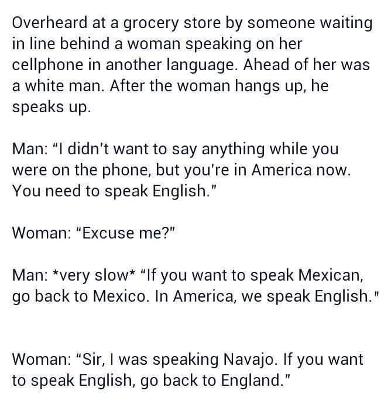

.

However, these cautions about Bradbury’s story circulated far less extensively than the original post. Later in 2016, the *New York Times* found something similar about [a fake story that had circulated about paid protesters bused to a Trump event](https://www.nytimes.com/2016/11/20/business/media/how-fake-news-spreads.html?_r=0). The original poster realized the error of his claims and tried to retract them, but his retractions circulated far less extensively than his original inflammatory post.

As our readings showed, “fake news” isn’t a phenomenon new to the 21st century, but the operations of online platforms may exacerbate problems inherent to human discernment. What qualities do stories like these share with the memes and gifs we discussed last week? Why are we so susceptible to stories like these, and how do our own biases relate to the media through which we find information? And of course there’s the big question: what can be done about fake news?

# In-class Exercise: 10-04 and 10-05

## Designing a Bot

Today you’re going to work in pairs to design a bot. It could be a Twitter bot, or it could be another kind of automated producer of content.

You won’t be coding the bot (though you could try after this if you have the interest and ability) but you will be planning its operations quite formally. This does mean you can be ambitious: you only need to explain the process your bot would need to follow to create your intended output, but you do not need to understand precisely how to implement those steps in reality.

### What Kind of Bot?

You can design a bot of any kind, really, including:

1. A bot that creates literature, either by mashing up existing sources or by procedurally generating new material;
2. An activist bot that seeks to intervene in social or political conversations;
3. A non sequitur, mashup, or joke bot (this might overlap with #1) that makes the internet a slightly weirder place

Let’s avoid Mad Libs bots for this exercise, in part because they don’t require as much planning and in part because we already discussed one of these in detail. If you have an incredibly compelling idea for a Mad Libs-style bot I’m willing to listen, but don’t invest too much time in it until I’ve approved of your plan.

### The Ingredients

In order to plan a bot, you will need:

1. Source data. This is a broad category, and can include:
2. data drawn automatically from other websites, perhaps through an API (application programming interface). Think here about twitter bots that mashup other people’s twitter posts.
3. metadata drawn from other websites. Metadata is data about data, such as information on authors, dates, revision history, and so forth. Think about the bot that traces edits made to Wikipedia from Congress. It is using Wikipedia’s metadata about the IP addresses of its editors’ computers to identify the edits pertinent to the bot.
4. material you create and/or maintain, perhaps stored in text files or spreadsheets. Think about the procedurally generated poems we read. Most of these are drawing not from the wild, wild web but instead from smaller datasets created expressly for the purpose of generating those poems.
5. There are probably other possibilities.
6. An understanding of how your source data is structured. It won’t be enough to say “We’ll combine X with Y.” How precisely will you combine those sources? Do they use similar syntactic structures that will make breaking them apart and re-joining them simple? From your data sources, what will you want to retain and what might you need to pass over or discard? That is, you likely can’t use every bit of your sources, so what can you use and what can you not? What are the pieces of your data and precisely how will they be split, reworked, recombined, etc.?
7. A clear sense of what your final product should look like. This may well be a *structural* understanding. The specific products of your bot may have qualities of randomness, but you should understand the general structure of those products.

### What You Will Submit

A wireframe demonstrating how your bot will operate. You can draw this on paper or produce it on a computer, but it should visually show your bot’s inputs, transformations, and outputs. It should be relatively detailed in describing all three so that I can fully understand what you want your bot to do and how.

# In-class Exercise: 09-28

## Deciphering a Program

Below you’ll find a snippet of some code that we work with in my [Technologies of Text](http://s17tot.ryancordell.org/) class. Today I just want to look at the code together and work to decipher it. You’ll be in groups and I want you to try and answer, to the best of your ability:

1. From what point does the code begin? In other words, what’s its source data?
2. What does this code *do*? When it’s run, what is the final product?
3. How does the code get from its source data to that final product? Which of the intervening steps can you separate out and understand?
4. This last step is more abstract, but how are the operations of this code *similar* to writing, and how are they *distinct*?

# Mystery Code

```r
my_wordnik_key <- "YOUR_API_KEY_GOES_HERE"

# the line below will set the 'default' part of
# speech for your calls to Wordnik, but you will be
# able to override this setting in later code.
wordnik_pos = "adjective"

#
random_word <- function(key = my_wordnik_key, pos = wordnik_pos,
    min_count = 100, n = 1, min_length = 5, max_length = 10) {

    param <- paste0("words.json/randomWords?hasDictionaryDef=true",
        "&minCorpusCount=", min_count, "&minLength=",
        min_length, "&maxLength=", max_length, "&limit=",
        n, "&includePartOfSpeech=", pos)

    raw = birdnik:::query(key = key, params = param)
    do.call(rbind, lapply(raw, as.data.frame))

}

random_word(pos = "verb", n = 5, min_count = 1000)
random_word(pos = "interjection", n = 10, min_count = 100)

poem_word <- function(x) {
    random_word(pos = x, n = 1, min_count = 1000)[,
        2] %>% as.character()
}

poem_word("interjection")

poem <- paste(c(poem_word("verb"), " thy ", poem_word("noun"),
    " from ", poem_word("preposition"), " my ", poem_word("noun"),
    ", and ", poem_word("verb"), " thy ", poem_word("noun"),
    " from ", poem_word("preposition"), " my ", poem_word("noun"),
    "! \nQuoth the Ravbot, '", poem_word("interjection"),
    "!'"), collapse = "")

cat(poem)

setup_twitter_oauth("YOUR_CONSUMER_KEY_GOES_HERE",
    "YOUR_CONSUMER_SECRET_GOES_HERE", "YOUR_ACCESS_TOKEN_GOES_HERE",
    "YOUR_ACCESS_SECRET_GOES_HERE")

woeid <- "2367105"

trend <- getTrends(woeid)[, 1] %>% as_data_frame() %>%
    rename(trend = value) %>% filter(grepl("^#", trend))

poem <- paste(c(poem_word("verb"), " thy ", poem_word("noun"),
    " from ", poem_word("preposition"), " my ", poem_word("noun"),
    ", and ", poem_word("verb"), " thy ", poem_word("noun"),
    " from ", poem_word("preposition"), " my ", poem_word("noun"),
    "!\" \nQuoth the Ravbot, \"Never ", trend %>% sample_n(1),
    "!'"), collapse = "")

cat(poem)

if (nchar(poem) < 140) {
    tweet(poem)
} else {
    print("The poem is too long. Please rerun the generator and try again!")
}
```

# In-class Writing Prompt: 09-27

## [“The Truth of Fact, the Truth of Feeling”](https://subterraneanpress.com/magazine/fall_2013/the_truth_of_fact_the_truth_of_feeling_by_ted_chiang) by Ted Chiang

What is a memory? Increasingly, scientists are learning that memories are physically encoded in the brain. Scientists have even found ways to [suppress the formation of memories or selectively erase them](http://www.radiolab.org/story/91570-eternal-sunshine-of-the-spotless-rat/). Some of the best evidence, in fact, suggests that memories are reformed in the brain each time they are recalled, and that in fact the more often we recall something, [the less accurate that memory becomes](https://news.northwestern.edu/stories/2012/09/your-memory-is-like-the-telephone-game). Each time we remember something, we remember not the original event but instead our previous recollection of it, including all of the new ideas, connections, emotions, and other new contexts we’ve since associated with that memory. If you recall a moment with a dear childhood friend with whom you’ve since had a falling out, that memory will be tinged with anger, or sadness, or regret, and that tinge will echo through all future recollections of that moment, subtly reshaping it over time.

Given all that, would you sign up for Remem if it were available? Why or why not?

# In-class Writing Prompt: 09-18

Choose one of the following quotes about *17776*, one more about the form of the story and the other is more about its content. Either way, use your chosen quote to reflect on the story. You can take any path you’d like, but use specific examples if at all possible.

1. The first comes from [an online Q&A with the author of *17776*, SBNation (Sports Blog Nation) creative director Jon Bois](https://www.sbnation.com/2017/7/24/16003968/17776-questions-and-answers). When “@Crazyeyesdave” asked, “Do you think weird experimental stories like this have a future in sports writing or was this a singular event?” Bois responded:

   > I hope so. Maybe not distant-future sports sci-fi, but that’s only one of a thousand lanes. I could go really, really long on this answer. I’ll keep it short: There are countless different ways to write, and things and ideas to write about. And the Internet offers a kaleidoscope of different formats, media, tools, sights, and sounds to tell your stories. And most of us are not even trying to scrape the surface of any of it. We’ve got to start thinking of the Internet as something more than a glow-in-the-dark newspaper.
2. In a post about *17776* at the A.V. club, [William Hughes takes a more philosophical bent](https://news.avclub.com/the-future-of-football-is-post-human-despair-and-fasci-1798263717), arguing that:

   > “Bois’ serial story…seems largely concerned with the “why” of sports. That is, given the massive resources, time, and information at our disposal (not to mention those available to our descendants), why does communal game-playing still hold such an important place in society?”